# Avaliação Participativa de Impacto de Tecnologias Sociais · Cisternas, Quintais Produtivos e Ações de ATER

Extensão Rural

Prof. Dr. Luiz Diego Vidal Santos

## Abertura Visão Geral da Aula

Roteiro da aula Tópicos principais

- 1 O que é avaliação de impacto e por que participativa?
- 2 Métodos participativos de avaliação
- 3 Indicadores para tecnologias sociais
- 4 Estudo de caso: cisternas no semiárido
- 5 Oficina prática: construindo uma avaliação
- 6 Análise qualitativa dos resultados

Objetivo central Avaliação construída com as comunidades

Capacitar o estudante de Engenharia Agronômica a planejar e conduzir uma avaliação participativa de impacto de tecnologias sociais implantadas no meio rural, utilizando indicadores construídos com as comunidades.

Dos marcos teóricos de Freire e Fetterman às ferramentas de campo e à análise quali-quantitativa.

# Avaliação de Impacto: Conceitos

## Impacto O que é avaliação de impacto e por que participativa?

Definição Mudanças intencionais ou não

**Avaliação de impacto** é o processo sistemático de identificar as **mudanças** — intencionais ou não — que uma intervenção (projeto, política, tecnologia) gerou na vida das pessoas e nos sistemas em que estão inseridas.

| Tipo | Momento | Foco |
| --- | --- | --- |
| **Ex ante** | Antes da ação | Viabilidade e projeção |
| **De processo** | Durante | Ajustes e aprendizados |
| **Ex post** | Após conclusão | Resultados e impactos |

Abordagem dialógica Por que participativa?

A avaliação convencional (*top-down*) frequentemente:

- Ignora o **saber local**
- Mede apenas indicadores técnicos (produtividade, renda)
- Não capta **mudanças subjetivas** (autonomia, autoestima, organização comunitária)
- Produz resultados que **não retornam** às comunidades

A avaliação **participativa** envolve os beneficiários como **co-avaliadores**, não apenas informantes.

## Impacto Ciclo Temporal e Contraste de Abordagens

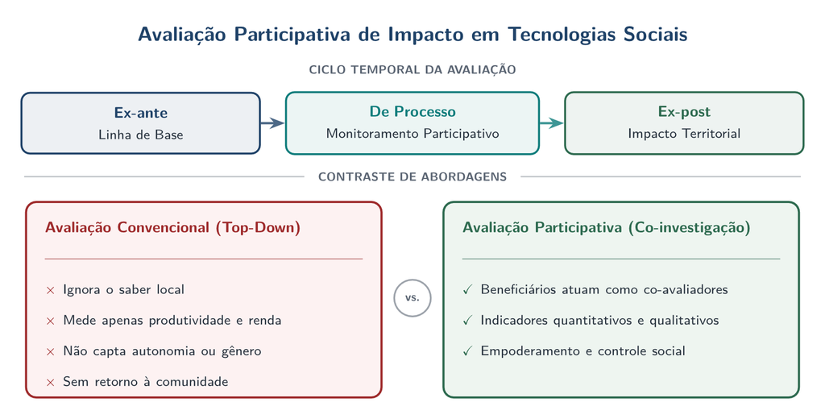

Ciclo temporal da avaliação (ex-ante, de processo e ex-post) e contraste entre avaliação convencional top-down e avaliação participativa.

Avaliação Participativa de Impacto em Tecnologias Sociais Integração entre linha de base, monitoramento participativo e análise de impacto territorial

Avaliar participativamente combina rigor metodológico (quantitativo e qualitativo) com empoderamento e controle social.

## Impacto Base Teórica: Freire e Empowerment Evaluation

Paulo Freire Extensão dialógica

A avaliação participativa é coerente com a extensão freireana:

- Comunidade como **sujeito** da avaliação
- Diálogo como **método**
- Indicadores definidos **com** e não **para** o público
- Resultados devolvidos na forma de **ação transformadora**

Fetterman (2001) Empowerment Evaluation

1. **Melhoria** — avaliar para melhorar, não para punir
2. **Apropriação comunitária** — a comunidade conduz o processo
3. **Inclusão** — todas as vozes, especialmente as marginalizadas
4. **Prestação de contas democrática** — transparência nos resultados
5. **Capacitação** — a comunidade aprende a avaliar

A avaliação deixa de ser auditoria externa e passa a ser instrumento pedagógico de autogestão comunitária.

# Métodos Participativos e Indicadores

## Métodos Ferramentas Participativas de Coleta

| Ferramenta | Descrição | Quando usar |
| --- | --- | --- |
| **Mapa Falante** | Desenho coletivo do território antes/depois da intervenção | Início da oficina — aquecer e contextualizar |
| **Linha do Tempo** | Reconstrução cronológica de mudanças percebidas | Avaliar processos ao longo dos anos |
| **Matriz de Indicadores** | Tabela com critérios definidos pelas famílias para pontuar mudanças | Quantificar percepções de forma estruturada |
| **Caminhada Transversal** | Percurso pelo território com observação participante | Triangular informações visuais e verbais |
| **Grupo Focal** | Discussão estruturada com 8–12 pessoas sobre temas-chave | Aprofundar percepções qualitativas |
| **Entrevista Semiestruturada** | Roteiro flexível aplicado individualmente | Captar experiências pessoais e sensíveis |

A combinação de ferramentas visuais, coletivas e individuais permite triangular percepções com observação direta em campo.

## Métodos Construção Participativa de Indicadores

Processo em 4 etapas Da escuta à métrica local

1. **Pergunta geradora:** *“O que mudou na sua vida depois da cisterna?”*
2. **Listagem livre:** cada participante fala mudanças percebidas
3. **Agrupamento temático:** facilitador organiza em categorias
4. **Definição de escala:** grupo define como “medir” cada indicador

| Nível | Descrição (definida pelo grupo) |
| --- | --- |
| **1** | “Não mudou nada” |
| **2** | “Melhorou um pouco” |
| **3** | “Melhorou bastante” |
| **4** | “Mudou completamente a vida” |

Dimensões avaliadas Categorias comuns de indicadores

- **Segurança hídrica** — acesso a água limpa, frequência de falta
- **Segurança alimentar** — diversificação da alimentação
- **Renda** — venda de excedentes, redução de gastos
- **Trabalho** — tempo gasto buscando água, divisão de tarefas
- **Saúde** — doenças de veiculação hídrica
- **Organização social** — participação em reuniões, associações
- **Gênero** — empoderamento feminino na gestão da água

# Estudo de Caso: Cisternas no Semiárido

## Casos Programa Um Milhão de Cisternas (P1MC)

Contexto e tecnologia social ASA · Agricultura familiar do semiárido

- **Articulação do Semiárido Brasileiro (ASA):** > **1,2 milhão** de cisternas de placa (**16.000 L** cada)
- **Por que é tecnologia social?** Materiais e mão de obra locais, troca de conhecimento entre famílias, respeito cultural e baixo custo replicável

| Indicador (ASA, 2023) | Antes | Depois |
| --- | --- | --- |
| Acesso à água potável | 23% | 89% |
| Doenças diarreicas (crianças) | Frequente | Rara |
| Tempo gasto buscando água | 3–5 h/dia | < 30 min/dia |
| Mulheres em associações | 12% | 47% |
| Quintais produtivos ativos | 8% | 62% |

[figure not shown]

Painel do programa de cisternas de placa da Articulação do Semiárido Brasileiro com família beneficiada no Piauí.

Cisternas de placa e famílias do Semiárido (ASA) Wikimedia Commons · acervo da disciplina

## Casos Exemplo de Avaliação Participativa: Riacho Seco (BA)

**Comunidade fictícia: Riacho Seco (BA)** — 35 famílias atendidas, cisternas implantadas desde 2018. Matriz construída como resultado direto da oficina comunitária:

| Indicador (definido pelas famílias) | Nota média (1–4) | Evidência qualitativa |
| --- | --- | --- |
| **“Água na seca”** | **3,7** | “Antes dependia de carro-pipa, agora só peço quando a seca é muito longa” |
| **“Comida mais variada”** | **3,2** | “Plantei coentro, cebolinha, tomate — antes tudo vinha da feira” |
| **“Saúde das crianças”** | **3,5** | “Diminuiu as diarreias, a água é limpa” |
| **“Trabalho das mulheres”** | **3,8** | “Não carrego mais lata na cabeça, sobra tempo pra roça e reunião” |
| **“União da comunidade”** | **2,9** | “Quando construímos juntos, aprendemos a trabalhar em mutirão” |

# Oficina Prática e Análise

| Momento | Tempo | Atividade | Material |
| --- | --- | --- | --- |
| **Abertura** | 15 min | Apresentação, expectativas, regras de convivência | Flip chart |
| **Mapa Falante** | 30 min | Desenho coletivo: “como era antes × como é agora” | Papel kraft, canetões |
| **Linha do Tempo** | 20 min | Marcos importantes desde a implantação da tecnologia | Barbante, cartões |
| **Intervalo** | 15 min | Café com bolo (cortesia) | — |
| **Construção de Indicadores** | 40 min | Pergunta geradora → listagem → agrupamento → escala | Cartões, tarjetas |
| **Pontuação coletiva** | 30 min | Cada família pontua os indicadores (votação com adesivos) | Adesivos coloridos |
| **Grupo Focal** | 20 min | Aprofundamento de 2–3 indicadores mais relevantes | Gravador (com permissão) |
| **Devolutiva e encerramento** | 10 min | Síntese visual dos resultados, próximos passos | Cartaz-síntese |

## Oficina Fichas de Campo para Coleta e Síntese

Instrumento 1 Ficha individual do facilitador

- **Cabeçalho:** Comunidade · Data · Família nº · Nº de membros · Tecnologia avaliada
- **Indicadores (escala 1–4):**
  1. [Indicador 1] `[ ]`
  2. [Indicador 2] `[ ]`
  3. [Indicador 3] `[ ]`
  4. [Indicador 4] `[ ]`
  5. [Indicador 5] `[ ]`
- **Observações de campo:** registro de falas literais e contexto domiciliar

Instrumento 2 Ficha de síntese coletiva

- **Cabeçalho:** Comunidade · Nº de participantes (homens / mulheres)
- **Quadro-síntese:** `Indicador | Nota média | Evidência` (linhas 1 a 3+)
- **Pontos fortes da tecnologia:** síntese consensual do grupo
- **Pontos a melhorar:** gargalos técnicos ou organizacionais
- **Recomendações do grupo:** encaminhamentos para a comunidade e ATER

Padronizar fichas simples garante rastreabilidade sem engessar a escuta participativa durante a oficina.

## Análise Análise dos Resultados e Princípios Éticos

Dados quantitativos Síntese numérica

- **Estatística descritiva** das notas por indicador (média, mediana, moda)
- **Gráfico radar** com as dimensões avaliadas
- Comparar notas entre subgrupos (gênero, idade, tamanho do lote)

Dados qualitativos Bardin (2011)

- **Análise de conteúdo** das falas e anotações (Bardin, 2011)
- Identificar **categorias emergentes** — temas não previstos
- **Triangulação** — cruzar falas × observação × dados quantitativos

Princípios éticos Compromisso com a comunidade

1. **Consentimento informado** — explicar o propósito e obter autorização
2. **Anonimato** — não vincular falas a nomes no relatório
3. **Devolutiva** — retornar os resultados à comunidade
4. **Não-extração** — não beneficiar apenas o pesquisador
5. **Aprovação em CEP** — para pesquisas acadêmicas (TCC, dissertação)

## Oficina Exercício Proposto em Grupo

Atividade em grupo (4–5 alunos) Roteiro prático da avaliação

1. Escolham uma **tecnologia social** implementada no seu município (cisterna, fossa biodigestora, horta comunitária, etc.)
2. Planejem uma **oficina de avaliação participativa** seguindo o roteiro apresentado
3. Definam pelo menos **5 indicadores** com escala participativa
4. Elaborem as **fichas de campo**
5. Simulem a oficina com colegas da turma como “comunidade”
6. Apresentem os resultados em formato de **relatório técnico**

Critérios de entrega Avaliação da atividade

- **Formato:** relatório PDF + fichas preenchidas
- **Prazo:** 14 dias
- **Distribuição da nota:**
  - Planejamento: **25%**
  - Indicadores: **25%**
  - Simulação: **25%**
  - Relatório: **25%**

## Referências Referências Bibliográficas

Fundamentos metodológicos Avaliação e análise de conteúdo

- BARDIN, L. *Análise de Conteúdo*. Edições 70, 2011.
- CHAMBERS, R. Participatory Rural Appraisal (PRA). *World Development*, v. 22, n. 9, p. 1253–1268, 1994.
- FETTERMAN, D. M. *Foundations of Empowerment Evaluation*. Sage, 2001.

Tecnologias sociais e marco legal Semiárido e PNATER

- ASA BRASIL. *Programa Um Milhão de Cisternas — Relatório de Impacto*. Recife, 2023.
- BRASIL. *PNATER — Política Nacional de Assistência Técnica e Extensão Rural*. Lei nº 12.188/2010.